# Reproducible Research: Peer Assessment 1

This document describes the processing of the activity monitoring data of an individual. Data is taken from https://d396qusza40orc.cloudfront.net/repdata%2Fdata%2Factivity.zip on Sep 18 2015. It is then unzipped into a single .csv file.

Before running this markdown file in R studio, first run setwd() to get to the folder containing the .csv file.

## Loading and preprocessing the data

## What is mean total number of steps taken per day?

- What is mean total number of steps taken per day? We read in the CSV file and ignore the missing values.

```r
dataset <- read.csv("activity.csv")
sum(dataset$steps, na.rm=TRUE)
```

```
## [1] 570608
```

- Plot histogram of total number of steps taken each day

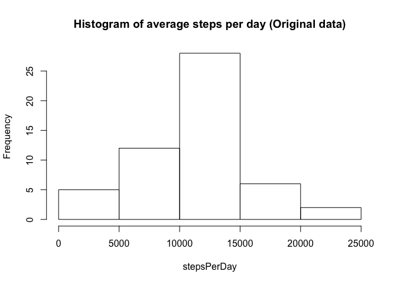

```r
summary <- tapply(dataset$steps, dataset$date, FUN=sum)
stepsPerDay <- array(summary)
hist(stepsPerDay, main="Histogram of average steps per day (Original data)")
```

- Mean of total number of steps taken each day - ignore missing values

```r
mean(stepsPerDay, na.rm=TRUE)
```

```
## [1] 10766.19
```

- Mediean of total number of steps taken each day - ignore missing values

```r
median(stepsPerDay, na.rm=TRUE)
```

```
## [1] 10765
```

## What is the average daily activity pattern?

- Time series plot of 5-min interval (x-axis) and average number of steps across all days (y-axis), ignoring NA values

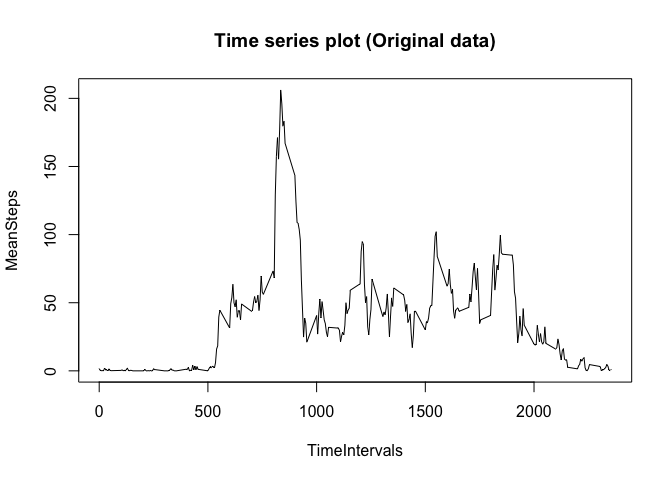

```r
summary2 <- tapply(dataset$steps, dataset$interval, FUN=mean, na.rm=TRUE)
MeanSteps <- array(summary2)
TimeIntervals <- dimnames(summary2)[[1]]
plot(TimeIntervals, MeanSteps, type="l", main="Time series plot (Original data)")
```

- 5-min interval with max number of steps on average

```r
TimeIntervals[which.max(MeanSteps)]
```

```
## [1] "835"
```

## Inputing missing values

- Total number of missing values in the dataset

```r
sum(is.na(dataset$steps))
```

```
## [1] 2304
```

- Use the mean for that 5-min interval to fill in missing values; display first few values

```r
head(MeanSteps)
```

```
## [1] 1.7169811 0.3396226 0.1320755 0.1509434 0.0754717 2.0943396
```

- Create new dataset with missing values filled in as in #2; display first few values

```r
dataset2 <- dataset
dataset2$steps <- ifelse(is.na(dataset2$steps),MeanSteps,dataset2$steps)
head(dataset2)
```

```
##       steps       date interval
## 1 1.7169811 2012-10-01        0
## 2 0.3396226 2012-10-01        5
## 3 0.1320755 2012-10-01       10
## 4 0.1509434 2012-10-01       15
## 5 0.0754717 2012-10-01       20
## 6 2.0943396 2012-10-01       25
```

- Redo histogram of total number of steps taken each day

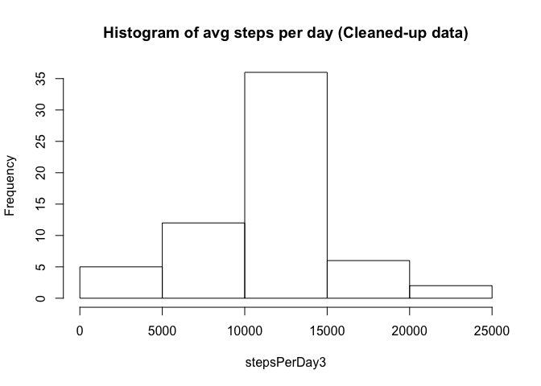

```r
summary3 <- tapply(dataset2$steps, dataset2$date, FUN=sum)
stepsPerDay3 <- array(summary3)
hist(stepsPerDay3, main="Histogram of avg steps per day (Cleaned-up data)")
```

Histogram now looks different.

- Mean of total number of steps taken each day - no need to ignore missing values

```r
mean(stepsPerDay3)
```

```
## [1] 10766.19
```

- Mediean of total number of steps taken each day - no need to ignore missing values

```r
median(stepsPerDay3)
```

```
## [1] 10766.19
```

Mean has not changed from first part of assignment. Median has changed from first part of assignment Inputing missing data increases the total daily number of steps.

## Are there differences in activity patterns between weekdays and weekends?

- Create new factor variable in new dataset with 2 levels - “weekday” and “weekend”. Display first few values

```r
dataset2$weekdayOrWeekend <- ifelse((weekdays(as.Date(dataset2$date)) %in%
                                       c("Saturday", "Sunday")),
                                    "weekend","weekday")
head(dataset2)
```

```
##       steps       date interval weekdayOrWeekend
## 1 1.7169811 2012-10-01        0          weekday
## 2 0.3396226 2012-10-01        5          weekday
## 3 0.1320755 2012-10-01       10          weekday
## 4 0.1509434 2012-10-01       15          weekday
## 5 0.0754717 2012-10-01       20          weekday
## 6 2.0943396 2012-10-01       25          weekday
```

- Time series plot of 5-min interval (x-axis) and average number of steps across all days (y-axis); no need to ignore NA values

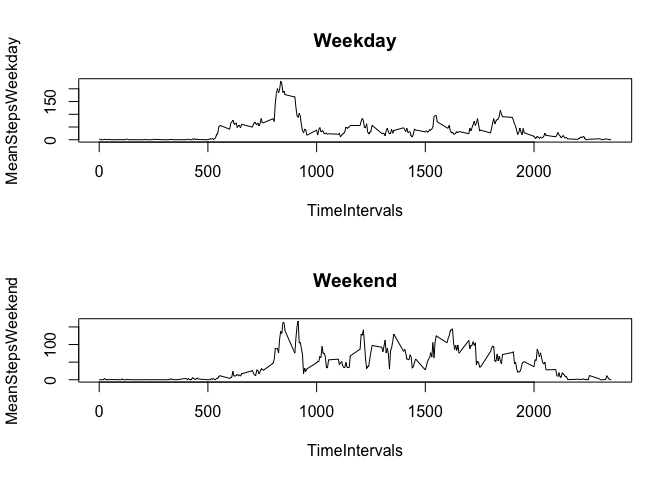

```r
weekdayData <- dataset2[dataset2$weekdayOrWeekend=="weekday",]
weekendData <- dataset2[dataset2$weekdayOrWeekend=="weekend",]
summaryWeekday <- tapply(weekdayData$steps, weekdayData$interval, FUN=mean)
summaryWeekend <- tapply(weekendData$steps, weekendData$interval, FUN=mean)

par(mfrow=c(2,1))
MeanStepsWeekday <- array(summaryWeekday)
TimeIntervals <- dimnames(summaryWeekday)[[1]]
plot(TimeIntervals, MeanStepsWeekday, type="l",main="Weekday")
MeanStepsWeekend <- array(summaryWeekend)
TimeIntervals <- dimnames(summaryWeekend)[[1]]
plot(TimeIntervals, MeanStepsWeekend, type="l",main="Weekend")
```